# *Eviota atriventris*

Here is an analysis of characters morphological characters from *E. atriventris*. We attempt to compare morphologies from two geographic localities. Western populations were sampled primarily from Palau and Indonesia, while Eastern populations are primarily sampled from the Solomon Islands and Papua New Guinea. Phenotypic differences between the two suggest some level of divergence, so we attempt to find out if this is supported by other morphological and meristic characters.

My morphological analysis showed that only pelvic fin characteristics were variable, so I analysed four pelvic fin characters in the two color morphs.

## Branches

Here is a a histogram of all branch data of the 4th pevic ray.

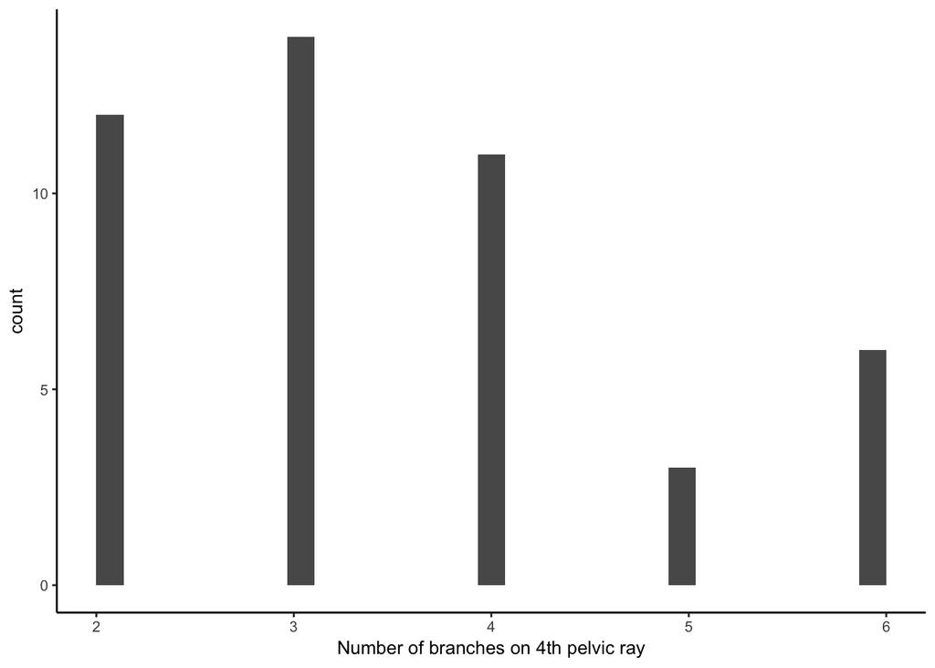

There is not a normal distribution but we will proceed with the analysis anyway. We would like to see the difference in 4th ray branch number in populations from Palau vs Papua New Guinea.

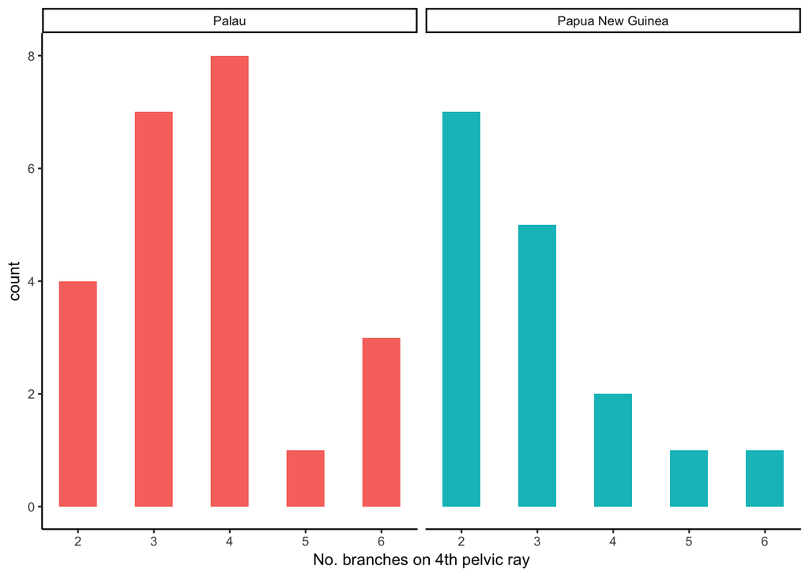

This histogram compares populations from the Eastern localities compared with the western localities.

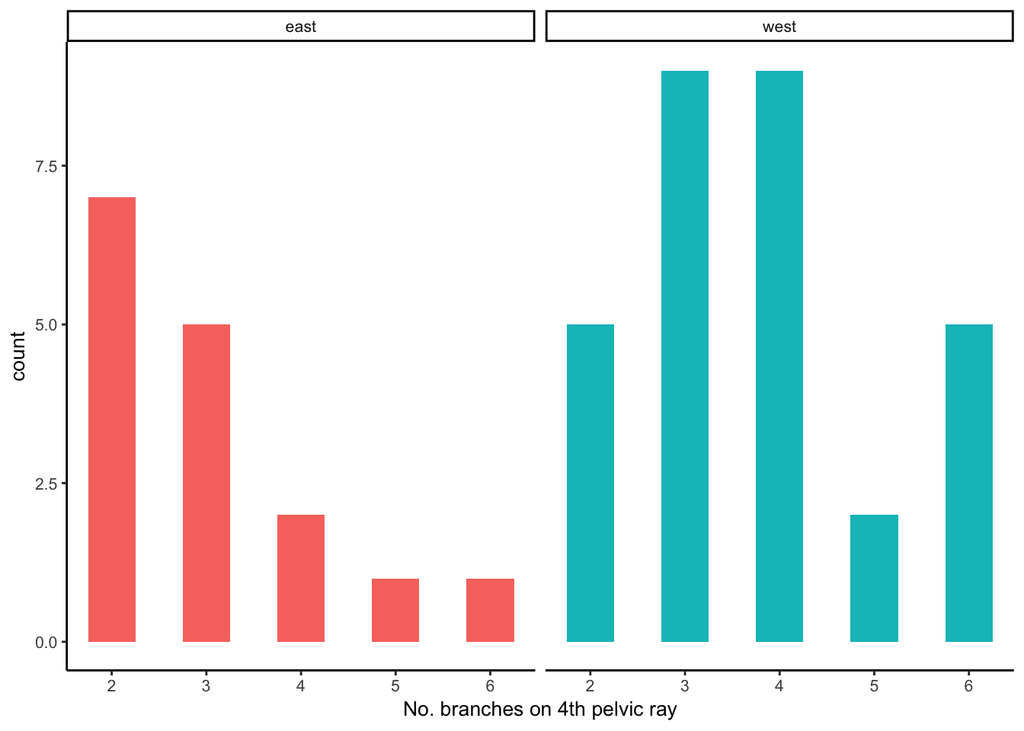

```
##
##  Welch Two Sample t-test
##
## data:  west$branches and east$branches
## t = 1.9901, df = 32.815, p-value = 0.05497
## alternative hypothesis: true difference in means is not equal to 0
## 95 percent confidence interval:
##  -0.01727863  1.55061196
## sample estimates:
## mean of x mean of y
##  3.766667  3.000000
```

## Other pelvic fin characters

we will attempt to use other pelvic characters to figure out if there will be differences based on other pelvic characters. Here is a table of all characters.

Pelvic fin morpholgy

| Specimen | DNA. | X | locality | haplotype | SL.mm. | sex | fifth_fourth_ratio | pelvic_length | membrane_length | branches | jaw_eye |
| --- | --- | --- | --- | --- | --- | --- | --- | --- | --- | --- | --- |
| ROM 92305 | no |  | Papua New Guinea | east | 17.9 | male | 0.79 | 3.5 | 0.75 | 2 | anterior margin of pupil |
| ROM 92305 | no |  | Papua New Guinea | east | 14.5 | male | 0.50 | 4.0 | 0.75 | 2 | anterior margin of pupil |
| ROM 92305 | no |  | Papua New Guinea | east | 14.3 | male | 0.50 | NA | 0.75 | NA | anterior margin of pupil |
| ROM 92309 | no |  | Papua New Guinea | east | 16.2 | female | 0.50 | 3.5 | 0.75 | 2 | middle of pupil |
| ROM 92309 | no |  | Papua New Guinea | east | 17.6 | male | NA | NA | NA | NA | middle of pupil |
| ROM 84482 | no |  | Palau | west | 17.9 | male | 0.50 | 4.1 | 0.50 | 6 | middle of pupil (see picture) |
| ROM 92322 | no |  | Papua New Guinea | east | 16.5 | female | 0.50 | 5.1 | 0.75 | 2 | anterior margin of pupil |
| ROM 92322 | no |  | Papua New Guinea | east | 12.2 | male | 0.38 | 3.8 | 0.33 | 3 | anterior margin of pupil |
| ROM 84498 | no |  | Palau | west | 17.8 | female | 0.46 | 4.9 | 0.50 | 6 | middle of pupil |
| ROM 74922 A | no |  | Palau | west | 13.9 | male | 0.46 | 4.6 | 0.50 | 4 | middle of pupil |
| ROM 74922 B | no |  | Palau | west | 14.1 | male | 0.50 | 4.4 | 0.50 | 3 |  |
| ROM 74922 C | no |  | Palau | west | 16 | male | 0.50 | 4.6 | 0.50 | 2 | anterior margin of pupil |
| ROM 74922 D | no |  | Palau | west | 14.4 | male | 0.50 | 4.6 | 0.50 | 2 | anterior margin of pupil |
| ROM 74922 E | no |  | Palau | west | 14.1 | male | 0.33 | 4.7 | 0.50 | 4 | middle of pupil |
| ROM 74922 F | no |  | Palau | west | 17.8 | female | 0.38 | 4.5 | 0.50 | 4 | anterior margin of pupil |
| ROM 74922 G | no |  | Palau | west | 14.9 | male | 0.44 | 4.5 | 0.50 | 4 | anterior margin of pupil |
| ROM 74922 H | no |  | Palau | west | 13.5 | male | 0.47 | 4.3 | 0.50 | 6 | anterior margin of pupil |
| ROM 74922 I | no |  | Palau | west | 14.2 | female | 0.40 | 4.3 | 0.50 | 3 | middle of pupil |
| ROM 74922 J | no |  | Palau | west | 14.4 | male | 0.32 | 3.7 | 0.33 | 3 | anterior margin of pupil |
| ROM 92298 | no |  | Papua New Guinea | east | 11.5 | male | NA | NA | NA | NA | anterior margin of pupil |
| ROM 88226 A | no |  | Palau | west | 12 | ?female | 0.48 | 4.0 | 0.50 | 4 | anterior margin of pupil |
| ROM 88226 B | no |  | Palau | west | 11.3 | ?female | 0.19 | 3.7 | 0.50 | 4 | anterior margin of pupil |
| ROM 88226 C | no |  | Palau | west | 16.5 | female | 0.45 | 4.7 | 0.50 | 5 | middle of pupil |
| ROM 88226 D | no |  | Palau | west | 9.9 | ?male | 0.38 | 2.9 | 0.50 | 2 | anterior margin of pupil |
| ROM 88226 E | no |  | Palau | west | 11.4 | male | NA | NA | NA | NA | anterior margin of pupil |
| ROM 88226 F | no |  | Palau | west | 14.3 | male | 0.49 | 4.1 | 0.50 | 3 | anterior margin of pupil |
| ROM 88226 G | no |  | Palau | west | 13.7 | female | 0.33 | 4.5 | 0.33 | 3 | anterior margin of pupil |
| ROM 88226 H | no |  | Palau | west | 14 | female | 0.38 | 4.0 | 0.33 | 2 | anterior margin of pupil |
| ROM 88226 I | no |  | Palau | west | 11.9 | male | 0.24 | 3.8 | 0.33 | 3 | anterior margin of pupil |
| ROM 88226 J | no |  | Palau | west | 11.9 | female | 0.34 | 3.5 | 0.33 | 4 | anterior margin of pupil |
| ROM 88226 K | no |  | Palau | west | 12.6 | male | 0.34 | 4.1 | 0.33 | 4 | anterior margin of pupil |
| ROM 88226 L | no |  | Palau | west | 11.3 | female | NA | NA | NA | NA | anterior margin of pupil |
| ROM 88226 M | no |  | Palau | west | 11.7 | male | 0.32 | 3.7 | 0.33 | 3 | anterior margin of pupil |
| ROM 88226 N | no |  | Palau | west | 10.5 | male | NA | NA | NA | NA | anterior margin of pupil |
| ROM 92314 | no |  | Papua New Guinea | east | 13.9 | female | 0.29 | 4.2 | 0.33 | 2 | anterior margin of pupil |
| ROM 92314 | no |  | Papua New Guinea | east | 17 | female | NA | NA | 0.33 | 3 | anterior margin of pupil |
| ROM 92291 | no |  | Papua New Guinea | east | 16 | male | 0.43 | 4.2 | 0.50 | 2 | anterior margin of pupil |
| WAM P34290 | EA1 | Lawidi, Milne Bay | Papua New Guinea | east | 14.6 | female | 0.44 | 4.3 | 0.33 | 4 | anterior margin of pupil |
| WAM P34290 | EA2 | Lawidi, Milne Bay | Papua New Guinea | east | 12.4 | male | 0.24 | 3.8 | 0.33 | 3 | anterior margin of pupil |
| MVE 16-060 | EA13 | Yandina | Solomons | east | N | female | NA | NA | NA | NA | middle of pupil |
| MVE 16-060 | EA14 | Yandina | Solomons | east | broken | female | NA | NA | NA | NA | anterior margin of pupil |
| (no number) 1 | no | Lawadi, Milne Bay | Papua New Guinea | east | 15.1 | female | 0.53 | 4.5 | 0.33 | 3 | anterior margin of pupil |
| (no number) 2 | no | Lawadi, Milne Bay | Papua New Guinea | east | 19.2 | male | 0.49 | 4.9 | 0.75 | 6 | anterior margin of pupil |
| (no number) 3 | no | Lawadi, Milne Bay | Papua New Guinea | east | 17.3 | male | 0.44 | 5.0 | 0.75 | 4 | anterior margin of pupil |
| (no number) 4 | no | Lawadi, Milne Bay | Papua New Guinea | east | 12 | male | 0.42 | 3.8 | 0.75 | 2 | anterior margin of pupil |
| (no number) 5 | no | Lawadi, Milne Bay | Papua New Guinea | east | 17.2 | male | 0.39 | 5.4 | NA | 5 | middle of pupil |
| (no number) 6 | no | Lawadi, Milne Bay | Papua New Guinea | east | 13.8 | female | 0.39 | 3.8 | 0.75 | 3 | anterior margin of pupil |
| Eviota cf. nigrispina | CN1 | Kwatisore, Cendrawasih | Papua | west | 11.3 | female | NA | 4.8 | 0.33 | 6 | anterior margin of pupil |
| Eviota cf. nigrispina | CN2 | Kwatisore, Cendrawasih | Papua | west | 11.6 | female | 0.36 | 3.6 | 0.33 | 6 | middle of pupil |
| Eviota cf. nigrispina | CN3 | Kwatisore, Cendrawasih | Papua | west | 7 |  | NA | NA | NA | NA | anterior margin of pupil |
| (no number) 7 | EA8 | Nankivelle | Brunei | west | 9.5 |  | 0.44 | 2.7 | NA | 2 | anterior margin of pupil |
| MVE 17-019 | EA15 | Kwatisore, Cendrawasih | Papua | west | 12.1 | female | 0.26 | 3.4 | 0.75 | 4 | anterior margin of pupil |
| MVE 17-019 | EA16 | Kwatisore, Cendrawasih | Papua | west | 12.7 | female | 0.45 | 3.3 | 0.75 | 3 | anterior margin of pupil |
| (no number) 8 | EA9 | Aluji Bay | Raja Ampat | west | 13 | female | 0.33 | 3.3 | 0.75 | 5 | anterior margin of pupil |
| (no number) 10 | EA10 | Aluji Bay | Raja Ampat | west | 13.4 | female | 0.49 | 3.7 | 0.75 | 3 | anterior margin of pupil |

Using this data, we constructed a Principal Component analysis to look for any sign of grouping by population.

This table of loadings values displays the values of each character represented on each axis of the pca plot.

```
##
## Loadings:
##                    Comp.1 Comp.2 Comp.3 Comp.4
## fifth_fourth_ratio  0.558 -0.159  0.738  0.346
## pelvic_ratio       -0.556  0.219  0.672 -0.437
## fin_membrane        0.596  0.102        -0.794
## branches           -0.157 -0.957        -0.242
##
##                Comp.1 Comp.2 Comp.3 Comp.4
## SS loadings      1.00   1.00   1.00   1.00
## Proportion Var   0.25   0.25   0.25   0.25
## Cumulative Var   0.25   0.50   0.75   1.00
```

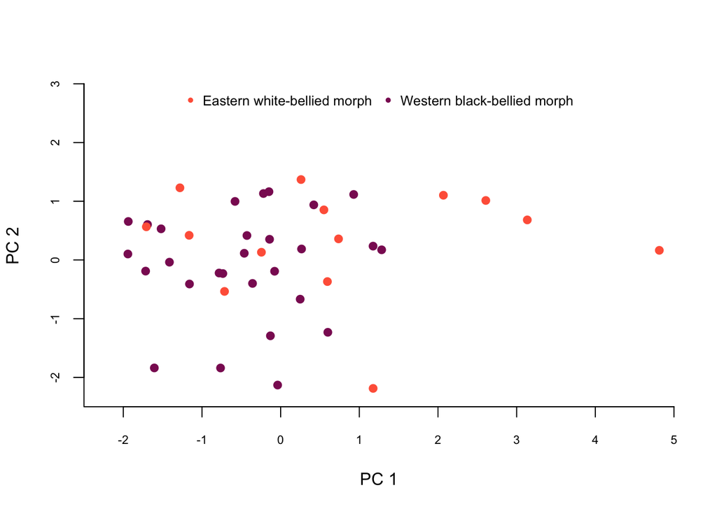

This is interesting in light of the drastic difference in mitochondrial DNA and coloration that we observe in Eviota.